# Sangho_CroqPain

```python
import pandas as pd
import numpy as np
import seaborn as sns
import matplotlib.pyplot as plt
import statsmodels.api as sm
from statsmodels.stats.outliers_influence import variance_inflation_factor
from scipy.stats import boxcox
import pyrsm as rsm
import os

os.chdir('/home/jovyan/Desktop/Desktop - Sangho’s MacBook Pro/UCSD/Class/2023_Fall/MGTA453-Business Analysis/CroqPain')

df = pd.read_parquet('CroqPain.parquet')

df.head()
```

|  | STOR | EARN | K | SIZE | EMPL | total | P15 | P25 | P35 | P45 | P55 | INC | COMP | NCOMP | NREST | PRICE | CLI | CITY |
| --- | --- | --- | --- | --- | --- | --- | --- | --- | --- | --- | --- | --- | --- | --- | --- | --- | --- | --- |
| 0 | 1 | 28339.672620 | 861.0718 | 129 | 14.0 | 8.58 | 0.98 | 1.28 | 0.56 | 1.00 | 3.10 | 27.6 | 8 | 1 | 45 | 16.1 | 129 |  |
| 1 | 2 | -1.455001 | 630.3028 | 91 | 12.0 | 8.46 | 1.29 | 0.72 | 1.20 | 1.49 | 3.10 | 28.3 | 2 | 2 | 27 | 11.4 | 116 |  |
| 2 | 3 | 68.932678 | 1074.4360 | 140 | 13.0 | 19.25 | 2.94 | 2.49 | 3.71 | 4.03 | 5.27 | 30.2 | 5 | 4 | 5 | 21.7 | 142 |  |
| 3 | 4 | 202.073327 | 882.0064 | 184 | 7.0 | 20.92 | 3.57 | 4.93 | 4.42 | 4.30 | 2.96 | 27.6 | 2 | 1 | 7 | 11.8 | 138 |  |
| 4 | 5 | 115.778511 | 930.6688 | 144 | 14.0 | 11.66 | 1.70 | 1.14 | 2.20 | 2.14 | 2.63 | 33.9 | 1 | 3 | 25 | 16.6 | 126 |  |

### Before you start ...

There is a problem in the data file `CroqPain.parquet` (i.e., the data needs some 'cleaning'). Find the issue and propose a fix before you continue with the analysis.

- Hint: Check data histograms

Post questions on Piazza as needed. Discuss your "fix" with the TAs during a work session or post your proposed data "fix" on Piazza as a private post. Apply your fix and "store" it into a dataset called `CroqPainFix`.

### Goal

- build a regression model to forecast earnings (EARN) for potential new outlets based on the data from the existing 60 stores.

#### The predictors in this model could be

- capital (K),
- store size (SIZE),
- demographic factors (P15, P25, P35, P45, P55, total),
- average income (INC),
- competition factors (COMP, NCOMP, NREST),
- rent price (PRICE),
- cost of living index (CLI).

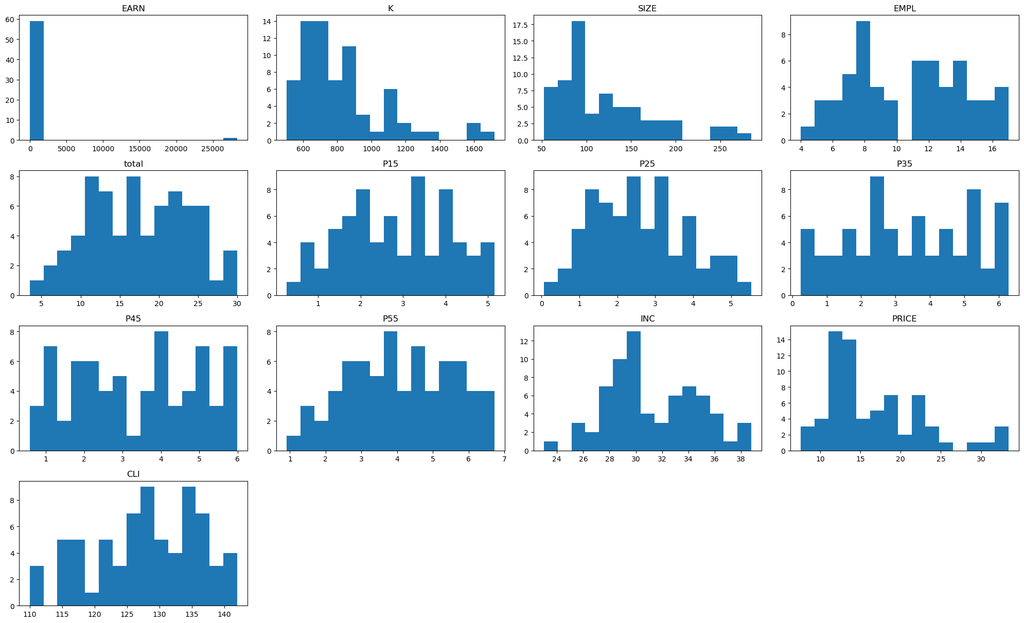

```python
# Plotting histograms for each numerical column
num_columns = df.select_dtypes(include=['float64', 'int64']).columns

selected_columns = ['EARN', 'K', 'SIZE', 'EMPL', 'total', 'P15', 'P25', 'P35', 'P45', 'P55', 'INC', 'PRICE', 'CLI']

plt.figure(figsize=(20, 15))
for i, col in enumerate(selected_columns, 1):
    plt.subplot(5, 4, i)
    plt.hist(df[col].dropna(), bins=15)
    plt.title(col)

plt.tight_layout()
plt.show()
```

# Finding

- We should focus on creating histograms for variables like 'EARN', 'K', 'SIZE', 'EMPL', 'P15', 'P25', 'P35', 'P45', 'P55', 'total', 'INC', 'PRICE', and 'CLI'. These are all numerical and represent continuous or count data, making histograms suitable for visualizing their distributions.

# Transforming

- Skewness to make their distributions as normal as possible

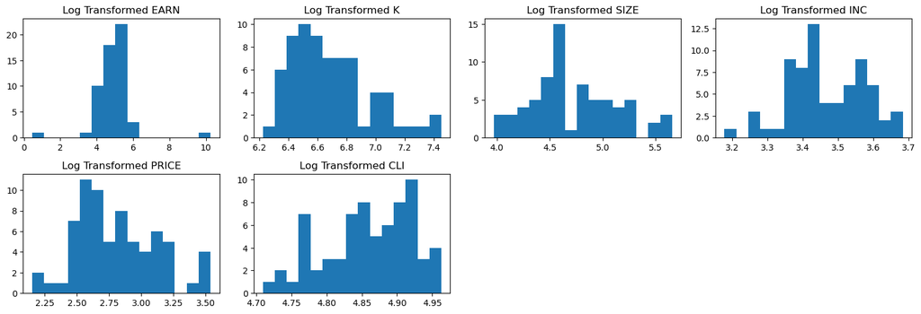

```python
# Selecting the relevant columns for transformation
cols_to_transform = ['EARN', 'K', 'SIZE', 'INC', 'PRICE', 'CLI']
df_transformed = df[cols_to_transform].copy()

# Applying log transformation (adding a small value to avoid log(0))
# Using numpy's log1p which is log(x + 1) to handle zero values
df_transformed = np.log1p(df_transformed)

# Plotting histograms after transformation
plt.figure(figsize=(15, 10))
for i, col in enumerate(cols_to_transform, 1):
    plt.subplot(4, 4, i)
    plt.hist(df_transformed[col].dropna(), bins=15)
    plt.title(f'Log Transformed {col}')

plt.tight_layout()
plt.show()
```

- K, Price is still Right Skewed, and CLI is left skewed.

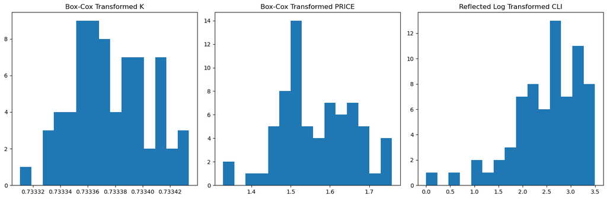

```python
# For right-skewed data ('K' and 'PRICE'), Box-Cox transformation
# Box-Cox requires all values to be positive, so add a small value to avoid zero or negative values
df_transformed['K_boxcox'], _ = boxcox(df['K'] + 0.01)
df_transformed['PRICE_boxcox'], _ = boxcox(df['PRICE'] + 0.01)

# For left-skewed data ('CLI'), we use a reflection (subtracting from a constant) and then log transformation
max_cli = df['CLI'].max() + 1
df_transformed['CLI_reflected_log'] = np.log(max_cli - df['CLI'])

# Plotting histograms after further transformations
plt.figure(figsize=(15, 5))

# Box-Cox transformed histograms
plt.subplot(1, 3, 1)
plt.hist(df_transformed['K_boxcox'].dropna(), bins=15)
plt.title('Box-Cox Transformed K')

plt.subplot(1, 3, 2)
plt.hist(df_transformed['PRICE_boxcox'].dropna(), bins=15)
plt.title('Box-Cox Transformed PRICE')

# Reflected log transformed histogram
plt.subplot(1, 3, 3)
plt.hist(df_transformed['CLI_reflected_log'].dropna(), bins=15)
plt.title('Reflected Log Transformed CLI')

plt.tight_layout()
plt.show()
```

- CLI is still left skewed

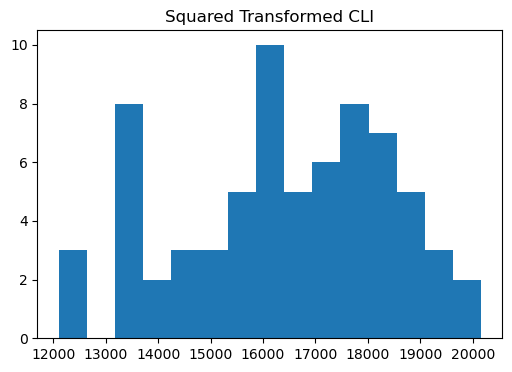

```python
# Applying a square transformation to 'CLI'
df_transformed['CLI_squared'] = df['CLI'] ** 2

# Plotting the histogram for the squared 'CLI'
plt.figure(figsize=(6, 4))
plt.hist(df_transformed['CLI_squared'].dropna(), bins=15)
plt.title('Squared Transformed CLI')
plt.show()
```

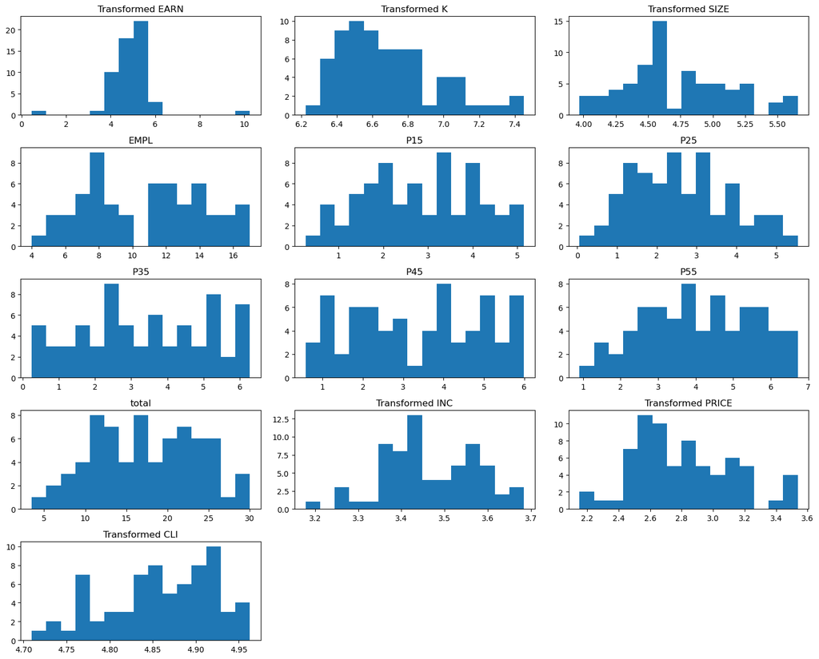

```python
# Correcting the code to display histograms for all selected columns after transformations
# Including both transformed and original columns that did not require transformation
all_columns = ['EARN', 'K', 'SIZE', 'EMPL', 'P15', 'P25', 'P35', 'P45', 'P55', 'total', 'INC', 'PRICE', 'CLI']
num_cols = len(all_columns)
num_rows = (num_cols + 2) // 3

plt.figure(figsize=(15, 12))
for i, col in enumerate(all_columns):
    plt.subplot(num_rows, 3, i + 1)
    data = df_transformed[col] if col in cols_to_transform else df[col]
    plt.hist(data.dropna(), bins=15)
    plt.title(f'{"Transformed " if col in cols_to_transform else ""}{col}')

plt.tight_layout()
plt.show()
```

- Now Scatter Plots

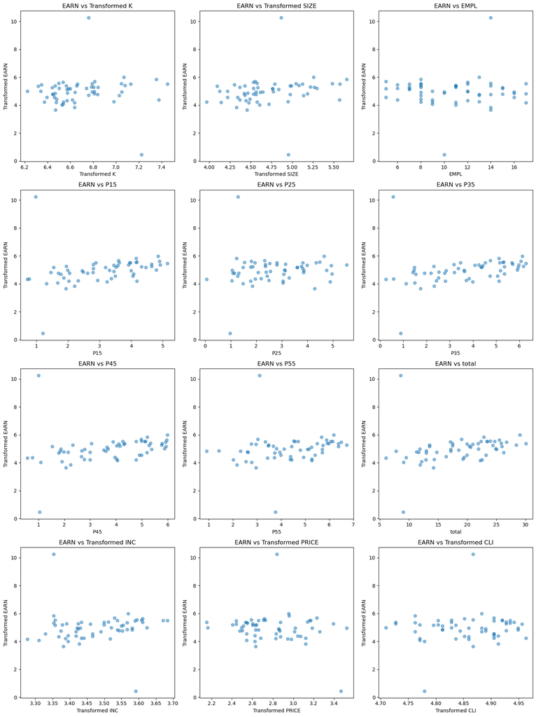

```python
# Scatter plots of EARN against other transformed variables
predictor_columns = ['K', 'SIZE', 'EMPL', 'P15', 'P25', 'P35', 'P45', 'P55', 'total', 'INC', 'PRICE', 'CLI']
num_predictors = len(predictor_columns)
num_rows = (num_predictors + 2) // 3

plt.figure(figsize=(15, num_rows * 5))

for i, col in enumerate(predictor_columns):
    plt.subplot(num_rows, 3, i + 1)
    x_data = df_transformed[col] if col in cols_to_transform else df[col]
    y_data = df_transformed['EARN']
    plt.scatter(x_data, y_data, alpha=0.5)
    plt.xlabel(f'{"Transformed " if col in cols_to_transform else ""}{col}')
    plt.ylabel('Transformed EARN')
    plt.title(f'EARN vs {"Transformed " if col in cols_to_transform else ""}{col}')

plt.tight_layout()
plt.show()
```

- I see some outliers. I will remove them

```python
def detect_and_remove_outliers(df, column):
    Q1 = df[column].quantile(0.25)
    Q3 = df[column].quantile(0.75)
    IQR = Q3 - Q1
    lower_bound = Q1 - 1.5 * IQR
    upper_bound = Q3 + 1.5 * IQR

    outliers = df[(df[column] < lower_bound) | (df[column] > upper_bound)]
    cleaned_df = df[(df[column] >= lower_bound) & (df[column] <= upper_bound)]

    return outliers, cleaned_df

# Example usage for 'EARN'
outliers, df_cleaned = detect_and_remove_outliers(df_transformed, 'EARN')

# You can inspect the outliers and the cleaned dataframe
print("Outliers:")
print(outliers)

print("\nCleaned DataFrame:")
print(df_cleaned.head())
```

```
Outliers:
         EARN         K      SIZE       INC     PRICE       CLI  K_boxcox  \
0   10.252053  6.759339  4.867534  3.353407  2.839078  4.867534  0.733389
13   0.454048  7.223560  4.955827  3.591818  3.465736  4.779123  0.733423

    PRICE_boxcox  CLI_reflected_log  CLI_squared
0       1.581289           2.639057        16641
13      1.742323           3.218876        13924

Cleaned DataFrame:
       EARN         K      SIZE       INC     PRICE       CLI  K_boxcox  \
2  4.247533  6.980481  4.948760  3.440418  3.122365  4.962845  0.733408
3  5.313567  6.783332  5.220356  3.353407  2.549445  4.934474  0.733391
4  4.760279  6.836977  4.976734  3.552487  2.867899  4.844187  0.733396
5  5.405706  7.078335  5.081404  3.511545  3.139833  4.927254  0.733415
6  5.683138  6.811346  4.553877  3.529297  3.230804  4.905275  0.733394

   PRICE_boxcox  CLI_reflected_log  CLI_squared
2      1.660586           0.000000        20164
3      1.486561           1.609438        19044
4      1.589915           2.833213        15876
5      1.665099           1.791759        18769
6      1.687960           2.197225        17956
```

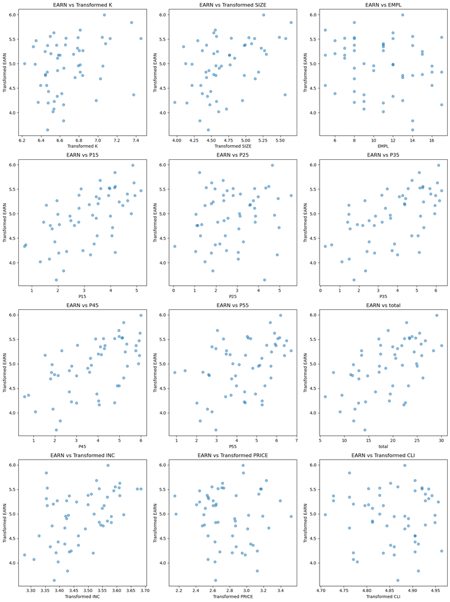

```python
# Re-defining the cols_to_transform list
cols_to_transform = ['K', 'SIZE', 'INC', 'PRICE', 'CLI']

# Update this list if you have additional or different columns in df_cleaned
predictor_columns = ['K', 'SIZE', 'EMPL', 'P15', 'P25', 'P35', 'P45', 'P55', 'total', 'INC', 'PRICE', 'CLI']
num_predictors = len(predictor_columns)
num_rows = (num_predictors + 2) // 3

plt.figure(figsize=(15, num_rows * 5))

for i, col in enumerate(predictor_columns):
    plt.subplot(num_rows, 3, i + 1)
    x_data = df_cleaned[col] if col in cols_to_transform else df[col]
    y_data = df_cleaned['EARN']  # Assuming 'EARN' is also in the cleaned data

    # Ensure x_data and y_data have the same length by dropping rows with NaN values in either
    valid_indices = x_data.notna() & y_data.notna()
    x_data = x_data[valid_indices]
    y_data = y_data[valid_indices]

    plt.scatter(x_data, y_data, alpha=0.5)
    plt.xlabel(f'{"Transformed " if col in cols_to_transform else ""}{col}')
    plt.ylabel('Transformed EARN')
    plt.title(f'EARN vs {"Transformed " if col in cols_to_transform else ""}{col}')

plt.tight_layout()
plt.show()
```

- Now, it looks better!

### Part (a)

Visualize the data: examine histograms and scatterplots. Look at correlations between variables and try to identify sources of concern. Pay particular attention to the correlation for `total` and `P15` through `P55`. Do these correlations make sense to you?

Apply a transformation to the variables `EARN`, `P15`, `P25`, `P35`, `P45`, `P55`, `COMP`, `NCOMP`, and `NREST` where you normalize them by `total`. You can apply this normalization by defining new variables such as `EARN_total` which is equal to `EARN` divided by `total`.

Evaluate correlations and regressions with both the transformed and un-transformed data. Which do you prefer and why?

When you run regressions, be sure to use the `VIF` feature in Radiant for a more rigorous evaluation of multicollinearity. As you are building a model, it can also be useful to examine standardized coefficients. Also, conduct linear regression validation checks by using the `dashboard` plots in the `Plots` tab (see section 6.6 in the book).

If interested, you can experiment with the `Stepwise selection` option in the *Summary* tab (i.e., click the checkbox) in the R version of Radiant (launched from RStudio). This is a feature in Radiant that uses a purely statistical approach to model building based on the Akaike Information Criterion (AIC). It will go through a series of steps and recommend a final model (see the bottom of the output). Compare the model selected using `Stepwise selection` to the model you arrived at yourself. Be critical and make a decision about the final model to recommend for Croq`Pain.

### Part (b)

Remember to use a subset of the `CroqPainFix` data with only the 50 stores opened up prior to 1994. After you build your regression model using `CroqPainFix` select the `Predict` tab in Radiant.

### Part (c)

This part can be completed using the same Radiant features applied earlier.

Visualize the data: examine histograms and scatterplots. Look at correlations between variables and try to identify sources of concern. Pay particular attention to the correlation for `total` and `P15` through `P55`. Do these correlations make sense to you?

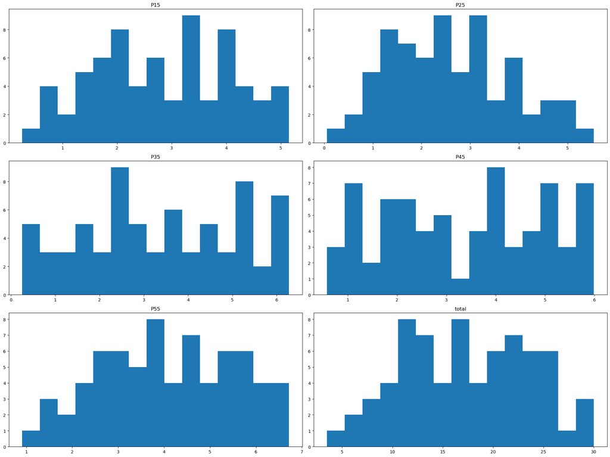

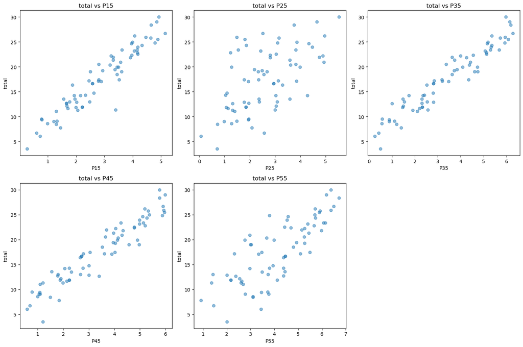

```
{'P15': 0.9497533289062252,
 'P25': 0.5961065293818569,
 'P35': 0.9595212996240409,
 'P45': 0.9516895225642815,
 'P55': 0.7895316487655104}
```

```python
# Histograms for Each Variable
plt.figure(figsize=(20, 15))
age_group_cols = ['P15', 'P25', 'P35', 'P45', 'P55', 'total']
for i, col in enumerate(age_group_cols):
    plt.subplot(3, 2, i + 1)
    plt.hist(df[col].dropna(), bins=15)
    plt.title(col)

plt.tight_layout()
plt.show()

# Scatterplots for 'total' vs each age group
plt.figure(figsize=(15, 10))
for i, col in enumerate(age_group_cols[:-1]):
    plt.subplot(2, 3, i + 1)
    plt.scatter(df[col], df['total'], alpha=0.5)
    plt.xlabel(col)
    plt.ylabel('total')
    plt.title(f'total vs {col}')

plt.tight_layout()
plt.show()

# Correlation Analysis for 'total' vs each age group
correlations = {col: df['total'].corr(df[col]) for col in age_group_cols[:-1]}
correlations
```

Apply a transformation to the variables `EARN`, `P15`, `P25`, `P35`, `P45`, `P55`, `COMP`, `NCOMP`, and `NREST` where you normalize them by `total`. You can apply this normalization by defining new variables such as `EARN_total` which is equal to `EARN` divided by `total`.

```python
df_normalized = df_cleaned.copy()

# Normalizing specified variables by 'total'
df_normalized['EARN_total'] = df['EARN'] / df['total']
df_normalized['P15_total'] = df['P15'] / df['total']
df_normalized['P25_total'] = df['P25'] / df['total']
df_normalized['P35_total'] = df['P35'] / df['total']
df_normalized['P45_total'] = df['P45'] / df['total']
df_normalized['P55_total'] = df['P55'] / df['total']
df_normalized['COMP_total'] = df['COMP'] / df['total']
df_normalized['NCOMP_total'] = df['NCOMP'] / df['total']
df_normalized['NREST_total'] = df['NREST'] / df['total']

# Displaying the first few rows of the new DataFrame with normalized variables
df_normalized.head()
```

|  | EARN | K | SIZE | INC | PRICE | CLI | K_boxcox | PRICE_boxcox | CLI_reflected_log | CLI_squared | EARN_total | P15_total | P25_total | P35_total | P45_total | P55_total | COMP_total | NCOMP_total | NREST_total |
| --- | --- | --- | --- | --- | --- | --- | --- | --- | --- | --- | --- | --- | --- | --- | --- | --- | --- | --- | --- |
| 2 | 4.247533 | 6.980481 | 4.948760 | 3.440418 | 3.122365 | 4.962845 | 0.733408 | 1.660586 | 0.000000 | 20164 | 3.580918 | 0.152727 | 0.129351 | 0.192727 | 0.209351 | 0.273766 | 0.259740 | 0.207792 | 0.259740 |
| 3 | 5.313567 | 6.783332 | 5.220356 | 3.353407 | 2.549445 | 4.934474 | 0.733391 | 1.486561 | 1.609438 | 19044 | 9.659337 | 0.170650 | 0.235660 | 0.211281 | 0.205545 | 0.141491 | 0.095602 | 0.047801 | 0.334608 |
| 4 | 4.760279 | 6.836977 | 4.976734 | 3.552487 | 2.867899 | 4.844187 | 0.733396 | 1.589915 | 2.833213 | 15876 | 9.929546 | 0.145798 | 0.097770 | 0.188679 | 0.183533 | 0.225557 | 0.085763 | 0.257290 | 2.144082 |
| 5 | 5.405706 | 7.078335 | 5.081404 | 3.511545 | 3.139833 | 4.927254 | 0.733415 | 1.665099 | 1.791759 | 18769 | 8.598658 | 0.179984 | 0.122188 | 0.221877 | 0.206749 | 0.229635 | 0.116369 | 0.349108 | 0.310318 |
| 6 | 5.683138 | 6.811346 | 4.553877 | 3.529297 | 3.230804 | 4.905275 | 0.733394 | 1.687960 | 2.197225 | 17956 | 15.414218 | 0.189474 | 0.122632 | 0.250000 | 0.261579 | 0.159474 | 0.000000 | 0.578947 | 4.684211 |

When you run regressions, be sure to use the `VIF` feature in Radiant for a more rigorous evaluation of multicollinearity. As you are building a model, it can also be useful to examine standardized coefficients. Also, conduct linear regression validation checks by using the `dashboard` plots in the `Plots` tab

[output not shown]

```
Linear regression (OLS)
Data                 : df_normalized
Response variable    : EARN_total
Explanatory variables: P15_total, P25_total, P35_total, P45_total, P55_total, COMP_total, NCOMP_total, NREST_total
Null hyp.: the effect of x on EARN_total is zero
Alt. hyp.: the effect of x on EARN_total is not zero

             coefficient  std.error  t.value p.value
Intercept         -10.77     14.193   -0.759   0.452
P15_total          56.28     39.261    1.433   0.159
P25_total          12.42     16.695    0.744   0.461
P35_total          -0.44     32.426   -0.014   0.989
P45_total          16.21     43.922    0.369   0.714
P55_total          15.06     18.086    0.833   0.409
COMP_total         -5.52      3.357   -1.645   0.107
NCOMP_total         3.36      2.377    1.415   0.164
NREST_total         0.79      0.331    2.392   0.021  *

Signif. codes:  0 '***' 0.001 '**' 0.01 '*' 0.05 '.' 0.1 ' ' 1

R-squared: 0.206, Adjusted R-squared: 0.065
F-statistic: 1.457 df(8, 45), p.value 0.2
Nr obs: 54
```

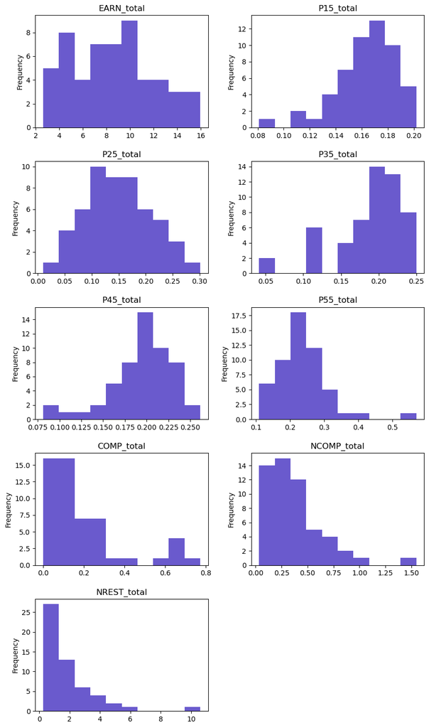

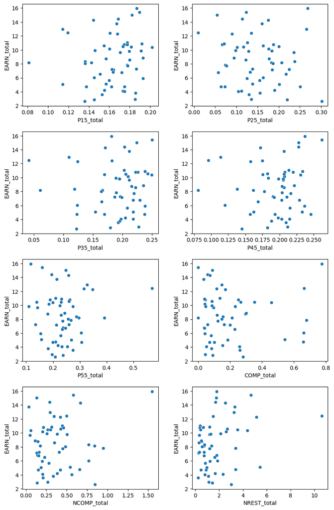

```python
reg = rsm.regress({"df_normalized": df_normalized}, rvar = "EARN_total", evar = ["P15_total", "P25_total", "P35_total", "P45_total", "P55_total", "COMP_total", "NCOMP_total", "NREST_total"])
reg.plot("distr")
reg.plot("scatter")
reg.summary()
```

# My Takeaway